# Lecture July 27: Frequency distributions - Standard Errors and Z-Scores

## Today: Frequency Distributions - Standard Errors and Z-Scores

## Minor announcement: Everyone did well on the midterm. I’ll hand them back tomorrow so you can start on corrections if you want some extra cushion for your grade. The grade *distribution* for all the work so far is heavily skewed with a median grade in the A/A- range and the low grade not much below that.

$$\\[5in]$$

## We’re working with the normal distribution here - either in the underlying DGP or because of Central Limit Theorem

## Previous discussion and how it fits

- 68-95-99.7 rule
- Need to tie sample to population **Today**
- Central Limit Theorem - ties sample to normal distribution
- Law of Large Numbers - ties the sample to the population conceptually
- Standard Error - ties sample measures to population
- Z-score - translates Standard Error to probability terms

$$\\[5in]$$

## Tying samples to populations

- Terms
  - statistics - sample
  - parameter - population
- We want to use the *sample* mean/median/etc to *estimate* the *population* version of the same value
- If you hear something like “We used the statistic to estime the parameter” it’s the same thing!

## Standard Error

- Quantifies the range around population value (parameter) for the sample value (the statistic)
- Usually the **mean** but you can figure a standard error for other statistics like the median
- Distance from the mean is a…

$$\\[5in]$$

## Standard Deviation

$$\\[5in]$$

- **The Standard Error of the Mean:**
  - Standard deviation measures dispersion relative to the mean
  - Standard error measures dispersion between the sample mean and the population mean
  - Standard error of the mean is the standard deviation of the sample divided by the square root of the sample size:

$\frac{s}{\sqrt{n}}$

$$\\[5in]$$

- I told you earlier that Standard Error **is** a Standard Deviation: It is the standard deviation of the *sample means*.
  - If we do 1000 trials of random, indendepent, identically distributed variables (random IID variables) from any distribution
  - The means of each trial are the sample means
  - Central Limit Theorem tells us that if the distribution of the sample means will converge to a normal distribution
  - If we made a vector of the means of the 10000 trials flipping a coin 20 times and plotted a histogram, it would look like this:

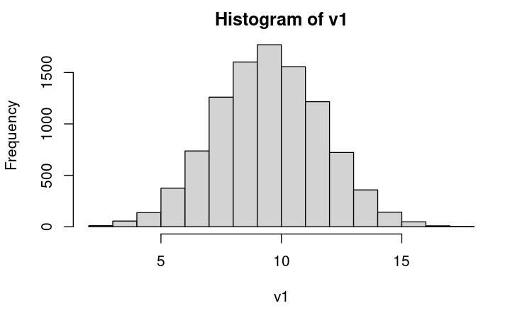

```
 + Law of Large Numbers tells us the sample statistic will approach the population parameter (sample mean will approach population mean)
 + That's the theoretical understanding.
 + Practically, it is confused and confusing. If we do an experiment with 500 subjects, it's one trial with one sample mean. When we start doing hypothesis tests, this gets a different treatment using the same measurements - standard error and z-score.
```

$$\\[5in]$$

## Z-Score

- Number of standard errors from the mean
- In terms of sample statistics and population parameters, it tells us the probability that that the actual population parameter is within a certain distance from our sample statistic.
- It lets us apply the rules of probability in a normal distribution
  - If we know the sample mean, $\bar{x}$, is 50
  - standard error, $\sigma$, is 1
  - We want to locate the population mean, $\mu$

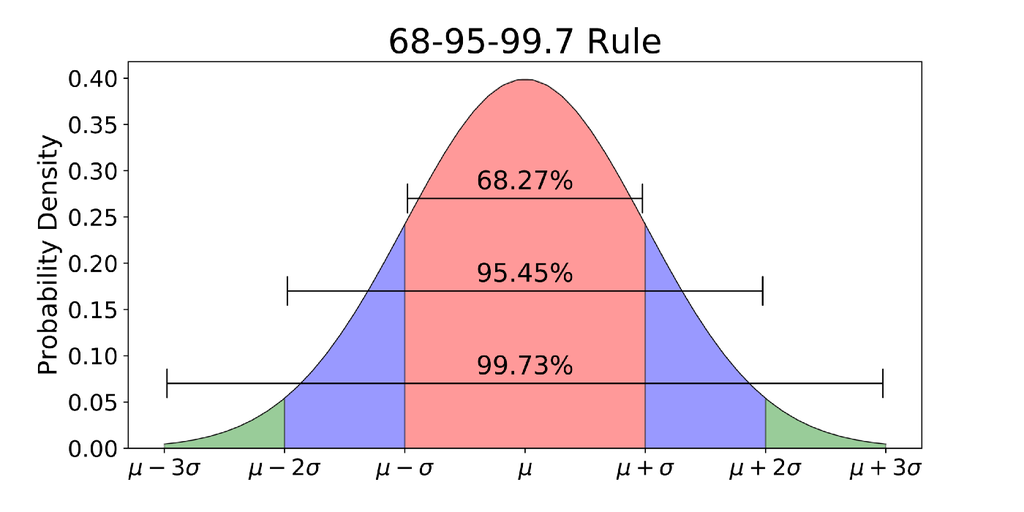

68-95-99 rule

- applying 68-95-99.7 would lead us to believe that there is a 99.7% probability that the true population mean is between $\bar{x} \pm 3 * SE$ or 50 $\pm$ 3. A 99.7% probability that the true population mean is between 47 and 53.
- **Confidence Interval** This is your first example of a **Confidence Interval**. The 99.7% *Confidence Interval* of the sample mean with a sample mean of 50 and standard error of 1 is 47 to 53.
- **The Z-score gives us a bit more precision**
- $z = \frac{x - \mu}{sigma}$
- *The Confidence Interval with the Z-Score is sample mean $\pm$ the Margin of Error which we get from (just for illustration at this point)*:

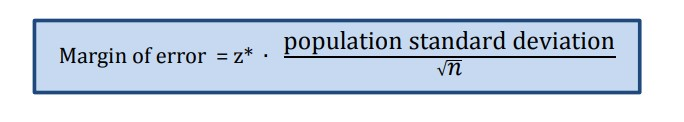

Margin of Error formula

$$\\[5in]$$

- Why not just follow the 68-95-99.7 rule and use 2?
  - 68-95-99.7 was just an approximation. Actual value is 95.45%

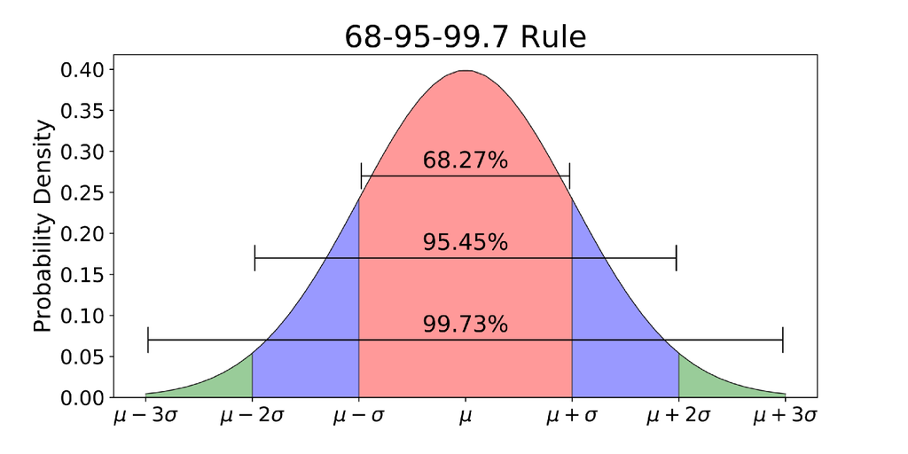

  68-95-99 rule

  - So the precise 5% level for Z-score is 1.96
  - The second answer is - 2 **is** actually the mental shortcut that in practical terms gets used in research when it comes to hypothesis testing
  - Journal articles in political science typically publish the outcomes of the test, called regression coefficients, with the standard error underneath:

```
===============================================
                        Dependent variable:
                    ---------------------------
                               dist
-----------------------------------------------
speed                        3.932***
                              (0.416)

Constant                     -17.579**
                              (6.758)

-----------------------------------------------
Observations                    50
R2                             0.651
Adjusted R2                    0.644
Residual Std. Error      15.380 (df = 48)
F Statistic           89.567*** (df = 1; 48)
===============================================
Note:               *p<0.1; **p<0.05; ***p<0.01
```

More on Z-scores and Standard Errors

https://www.statisticshowto.com/probability-and-statistics/z-score/

https://www.statisticshowto.com/probability-and-statistics/statistics-definitions/what-is-the-standard-error-of-a-sample/

https://www.investopedia.com/ask/answers/042415/what-difference-between-standard-error-means-and-standard-deviation.asp

https://www.investopedia.com/ask/answers/021115/what-difference-between-standard-deviation-and-z-score.asp